# Visualization Basics: Histograms & Boxplots

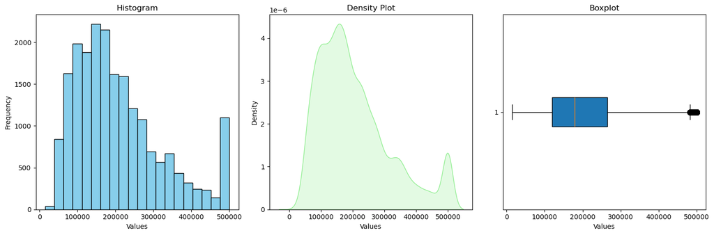

```
The data is Positive Skewness
The mean is  206855.81690891474
The median is  179700.0
The std is  115392.82040412253
The min is  14999.0
The max is  500001.0
The Q1 is  119600.0
The Q3 is  264775.0
The iqr is  145175.0
```

```python
import matplotlib.pyplot as plt
import seaborn as sns

def mean(data):
    if not data:
        return None
    return sum(data) / len(data)

# Function to calculate standard deviation
def std_dev(data):
    m = mean(data)
    var = sum((x - m) ** 2 for x in data) / len(data)
    return var ** 0.5

# Function to get quartiles
def get_quartile(data, q):
    """Returns the q-th quartile of a numeric dataset."""
    if not data:
        return None
    if q not in (1, 2, 3):
        print("Error: Quartiles can only be 1, 2, or 3.")
        return None

    data = sorted(data)
    n = len(data)
    pos = q * (n + 1) / 4

    if pos <= 1:
        return data[0]
    elif pos >= n:
        return data[-1]

    lower = int(pos) - 1
    upper = lower + 1
    fraction = pos - int(pos)
    return data[lower] + fraction * (data[upper] - data[lower])

# Clean the data (remove None values)
clean_data = [x for x in mdn_house if x is not None]

# Create a figure with 3 subplots
plt.figure(figsize=(15, 5))

# 1. Histogram
plt.subplot(1, 3, 1)
plt.hist(clean_data, bins=20, color='skyblue', edgecolor='black')
plt.title("Histogram")
plt.xlabel("Values")
plt.ylabel("Frequency")

# 2. Density Plot (KDE)
plt.subplot(1, 3, 2)
sns.kdeplot(clean_data, fill=True, color='lightgreen')
plt.title("Density Plot")
plt.xlabel("Values")
plt.ylabel("Density")

# 3. Boxplot
plt.subplot(1, 3, 3)
plt.boxplot(clean_data, vert=False, patch_artist=True,
            flierprops=dict(marker='o', color='red', markersize=8))
plt.title("Boxplot")
plt.xlabel("Values")

plt.tight_layout()
plt.show()

m = mean(clean_data)
std= std_dev(clean_data)
mdn = median(clean_data)
min_val = min(clean_data)
max_val = max(clean_data)
q3=get_quartile(clean_data,3)
q1=get_quartile(clean_data,1)
iqr=q3-q1
if m==mdn:
    print("The data is Symmetric skewness")
elif m >mdn:
    print("The data is Positive Skewness")
else:
    print("The data is Negative Skewness")
print("The mean is ",m)
print("The median is ",mdn)
print("The std is ",std)
print("The min is ",min_val)
print("The max is ",max_val)
print("The Q1 is ",q1)
print("The Q3 is ",q3)
print("The iqr is ",iqr)
```

**27. Plot distributions before and after log transformation and explain why transformation helps.**

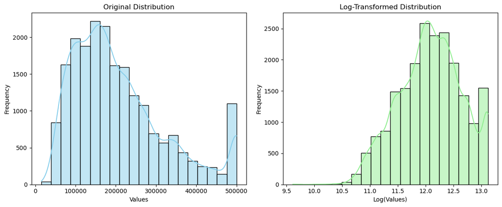

```
Original Data:
Mean: 206855.82, Median: 179700.00
Data may be right-skewed, with extreme high values.

Log-Transformed Data:
Mean: 12.08, Median: 12.10
After log transformation, the distribution is more symmetric and reduces the effect of extreme values.
```

```python
import matplotlib.pyplot as plt
import seaborn as sns
import math

# Clean the data (remove None and non-positive values for log)
clean_data = [x for x in mdn_house if x is not None ]

# Apply log transformation using math.log
log_data = [math.log(x) for x in clean_data]

# Plot distributions before and after log transformation
plt.figure(figsize=(12, 5))

# Original distribution
plt.subplot(1, 2, 1)
sns.histplot(clean_data, bins=20, kde=True, color='skyblue')
plt.title("Original Distribution")
plt.xlabel("Values")
plt.ylabel("Frequency")

# Log-transformed distribution
plt.subplot(1, 2, 2)
sns.histplot(log_data, bins=20, kde=True, color='lightgreen')
plt.title("Log-Transformed Distribution")
plt.xlabel("Log(Values)")
plt.ylabel("Frequency")

plt.tight_layout()
plt.show()

# Summary insights
mean_original = sum(clean_data) / len(clean_data)
median_original = sorted(clean_data)[len(clean_data)//2]

mean_log = sum(log_data) / len(log_data)
median_log = sorted(log_data)[len(log_data)//2]

print("Original Data:")
print(f"Mean: {mean_original:.2f}, Median: {median_original:.2f}")
print("Data may be right-skewed, with extreme high values.")

print("\nLog-Transformed Data:")
print(f"Mean: {mean_log:.2f}, Median: {median_log:.2f}")
print("After log transformation, the distribution is more symmetric and reduces the effect of extreme values.")
```

**28. Write code to dynamically choose bin size using data length (rule-based).**

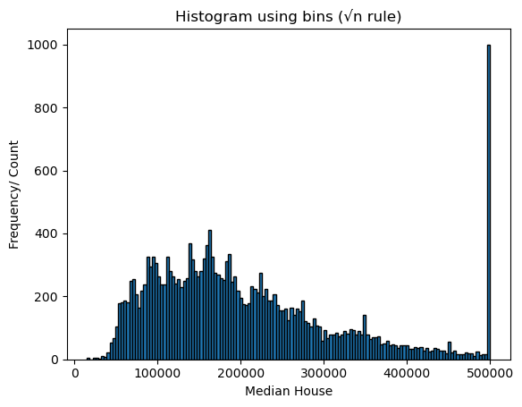

```python
import matplotlib.pyplot as plt
import math

clean_mdn_house = [x for x in mdn_house if x is not None]
n=len(clean_mdn_house)
# Using Square Root Rule for bin selection
bins = int(math.sqrt(n))

plt.hist(clean_mdn_house, bins=bins,edgecolor="black")
plt.title("Histogram using bins (√n rule)")
plt.xlabel("Median House")
plt.ylabel("Frequency/ Count")
plt.show()
```

**29. Compare visual spread using variance vs boxplot width and explain discrepancies**

```
Mean= 206855.81690891474
The variance of the data is  13315503000.818077
```

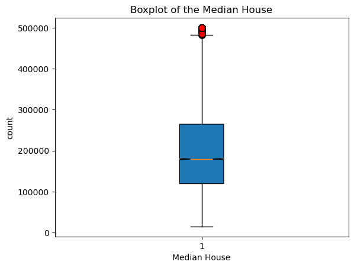

[output not shown]

```python
import matplotlib.pyplot as plt
def mean(data):
    return sum(data) / len(data)
def variance(data):
    m=mean(data)
    print("Mean=",m)
    return sum((x-m)**2 for x in data) / len(data)
clean_data = [x for x in mdn_house if  x is not None]
var = variance(clean_data)
print("The variance of the data is ", var)

plt.boxplot(clean_data,vert = True, patch_artist=True, notch=True,
           flierprops=dict(
        marker='o',
        markerfacecolor='red',
        markeredgecolor='black',
        markersize=8,
        alpha=0.7
    ))
plt.title("Boxplot of the Median House")
plt.xlabel("Median House")
plt.ylabel("count")
plt.show()
print("The variance shows a high numerical spread, indicating that median house values are widely dispersed around the mean."
      "However, the boxplot displays a moderately sized box, suggesting that most values are clustered within a narrower range. The presence"
      "of several high-value outliers increases the variance significantly but does not affect the box width. Hence, the difference arises because"
      "variance accounts for extreme values, whereas the boxplot emphasizes the spread of the central data.")
```

**30. Identify which visualization is most robust to outliers and justify your answer.**

The box plot is the most robust visualization to outliers because it uses the median and interquartile range (IQR) to summarize central tendency and spread, while plotting outliers as separate points. This ensures that extreme values do not distort the main visual representation of the data. Histograms rely on bin counts across the full data range, so outliers can stretch the axis and concentrate most observations into a few bins, hiding the true distribution of the majority of the data. Kernel Density Estimation (KDE) uses all data points to estimate a smooth density curve; extreme values influence the curve shape and bandwidth, often introducing long tails or skew that misrepresents the central distribution.

**31. Write code to save all generated plots automatically into a folder.**

```python
import matplotlib.pyplot as plt
import os
import seaborn as sns

# Create folder if not exists
folder_name = "saved_plots"
os.makedirs(folder_name, exist_ok=True)

# Example data
clean_data=[x for x in mdn_house if x is not None]

# Histogram
plt.figure()
plt.hist(clean_data, bins=5)
plt.title("Histogram")
plt.savefig(f"{folder_name}/histogram.png")
plt.close()

# Boxplot
plt.figure()
plt.boxplot(clean_data)
plt.title("Boxplot")
plt.savefig(f"{folder_name}/boxplot.png")
plt.close()


# Line plot
plt.figure()
plt.plot(clean_data)
plt.title("Line Plot")
plt.savefig(f"{folder_name}/line_plot.png")
plt.close()

# Kde plot
plt.figure()
sns.kdeplot(clean_data,fill=True)
plt.title("Kde plot")
plt.savefig(f"{folder_name}/kde_plot.png")
plt.close()

print("All plots saved successfully in 'saved_plots' folder.")
```

```
All plots saved successfully in 'saved_plots' folder.
```

**32. Given a business scenario (e.g., medical cost or housing price), explain which plot is most useful and why.**

**Housing Prices:** For housing prices, a boxplot is the most useful visualization because housing data often contains outliers, such as extremely expensive or very cheap properties. The boxplot effectively shows the median, interquartile range (IQR), and any outliers without letting extreme values distort the central spread. This allows stakeholders to quickly understand the typical price range of houses while clearly identifying rare expensive or low-priced properties.

**Medical Costs:** For medical costs, a histogram or KDE plot is more suitable because the data is usually continuous and right-skewed, with a majority of patients incurring moderate costs and a few having extremely high costs. These plots show the overall distribution of costs, allowing analysts to see common cost ranges and patterns in the data. Boxplots alone would hide much of this distribution detail, so histograms or KDE plots provide a more comprehensive view of the cost structure.

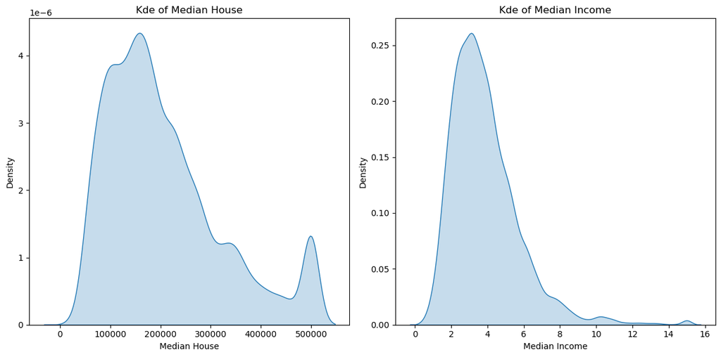

```python
import matplotlib.pyplot as plt
import seaborn as sns

clean_mdn_house = [x for x in mdn_house if x is not None]
clean_mdn_income = [x for x in mdn_income if x is not None]

plt.figure(figsize=(12,6))
plt.subplot(1,2,1)
sns.kdeplot(clean_mdn_house,fill=True)
plt.title("Kde of Median House")
plt.xlabel("Median House")
plt.ylabel("Density")

plt.subplot(1,2,2)
sns.kdeplot(clean_mdn_income,fill=True)
plt.title("Kde of Median Income")
plt.xlabel("Median Income")
plt.ylabel("Density")
plt.tight_layout()
plt.show()
```

**34. Combine visualization with statistics: print mean, median, std along with each plot.**

```
Median House → Mean: 206855.82, Median: 179700.00, Std: 115392.82
Median Income → Mean: 3.87, Median: 3.53, Std: 1.90
```

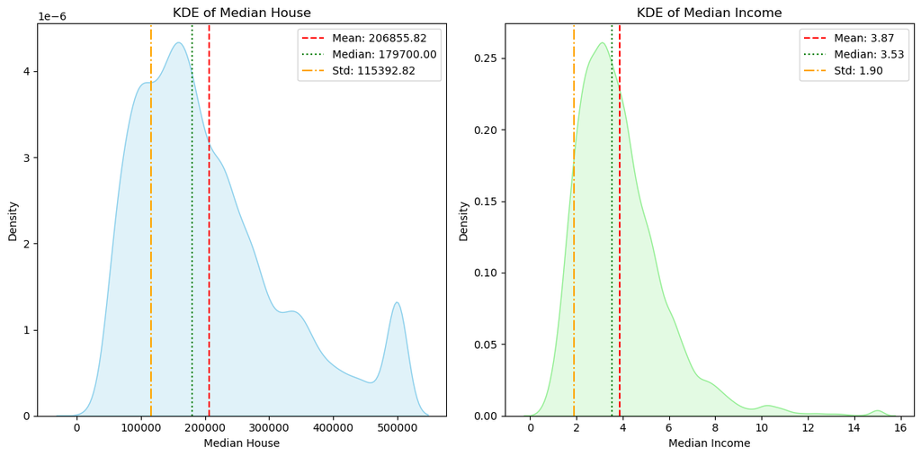

```python
import matplotlib.pyplot as plt
import seaborn as sns

# ---------- Your custom functions ----------
def mean(data):
    return sum(data) / len(data)

def median(data):
    data = sorted(data)
    n = len(data)
    mid = n // 2
    if n % 2 == 0:
        return (data[mid - 1] + data[mid]) / 2
    else:
        return data[mid]

def std_dev(data):
    m = mean(data)
    var = sum((x - m) ** 2 for x in data) / len(data)
    return var ** 0.5

#  Clean data
clean_mdn_house = [x for x in mdn_house if x is not None]
clean_mdn_income = [x for x in mdn_income if x is not None]

#  Plotting
plt.figure(figsize=(12,6))

#  Median House
plt.subplot(1,2,1)
sns.kdeplot(clean_mdn_house, fill=True, color="skyblue")

mean_h = mean(clean_mdn_house)
median_h = median(clean_mdn_house)
std_h = std_dev(clean_mdn_house)

print(f"Median House → Mean: {mean_h:.2f}, Median: {median_h:.2f}, Std: {std_h:.2f}")

plt.axvline(mean_h, color="red", linestyle="--", label=f"Mean: {mean_h:.2f}")
plt.axvline(median_h, color="green", linestyle=":", label=f"Median: {median_h:.2f}")
plt.axvline(std_h, color="orange", linestyle="-.", label=f"Std: {std_h:.2f}")

plt.title("KDE of Median House")
plt.xlabel("Median House")
plt.ylabel("Density")
plt.legend()

# ----- Median Income -----
plt.subplot(1,2,2)
sns.kdeplot(clean_mdn_income, fill=True, color="lightgreen")

mean_i = mean(clean_mdn_income)
median_i = median(clean_mdn_income)
std_i = std_dev(clean_mdn_income)

print(f"Median Income → Mean: {mean_i:.2f}, Median: {median_i:.2f}, Std: {std_i:.2f}")

plt.axvline(mean_i, color="red", linestyle="--", label=f"Mean: {mean_i:.2f}")
plt.axvline(median_i, color="green", linestyle=":", label=f"Median: {median_i:.2f}")
plt.axvline(std_i, color="orange", linestyle="-.", label=f"Std: {std_i:.2f}")

plt.title("KDE of Median Income")
plt.xlabel("Median Income")
plt.ylabel("Density")
plt.legend()

plt.tight_layout()
plt.show()
```

**35. Design a visualization pipeline function that takes raw data, removes outliers, and produces final plots.**

```
Median House → Mean: 190852.30, Median: 173200.00, Std: 95436.12
```

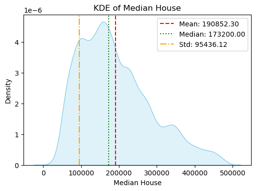

```
Median Income → Mean: 3.66, Median: 3.47, Std: 1.49
```

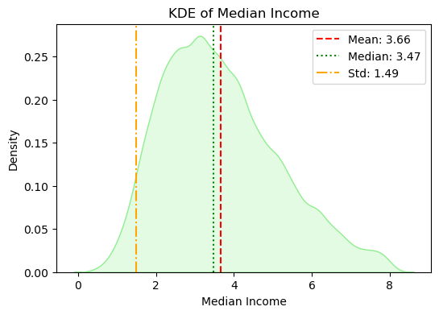

```python
import matplotlib.pyplot as plt
import seaborn as sns

# ---------- Custom Statistics ----------
def mean(data):
    return sum(data) / len(data)

def median(data):
    data = sorted(data)
    n = len(data)
    mid = n // 2
    if n % 2 == 0:
        return (data[mid - 1] + data[mid]) / 2
    else:
        return data[mid]

def std_dev(data):
    m = mean(data)
    var = sum((x - m) ** 2 for x in data) / len(data)
    return var ** 0.5

# ---------- Quartile / Outlier Functions ----------
def get_quartile(data, q):
    if not data:
        return None
    if q not in (1,2,3):
        print("Quartiles can only be 1,2,3")
        return
    data = sorted(data)
    n = len(data)
    pos = q * (n + 1) / 4
    if pos <= 1:
        return data[0]
    if pos >= n:
        return data[-1]
    lower = int(pos) - 1
    upper = lower + 1
    fraction = pos - int(pos)
    return data[lower] + fraction * (data[upper] - data[lower])

def remove_outliers(data):
    data = [x for x in data if x is not None]
    if not data:
        return []
    q1 = get_quartile(data, 1)
    q3 = get_quartile(data, 3)
    iqr = q3 - q1
    lower = q1 - 1.5 * iqr
    upper = q3 + 1.5 * iqr
    return [x for x in data if lower <= x <= upper]

# ---------- Visualization Pipeline ----------
def visualization_pipeline(raw_data, feature_name, color="skyblue"):
    # Step 1: Remove outliers
    clean_data = remove_outliers(raw_data)
    if not clean_data:
        print(f"No valid data for {feature_name}")
        return

    # Step 2: Compute statistics
    m = mean(clean_data)
    med = median(clean_data)
    s = std_dev(clean_data)

    # Print stats
    print(f"{feature_name} → Mean: {m:.2f}, Median: {med:.2f}, Std: {s:.2f}")

    # Step 3: Plot KDE
    plt.figure(figsize=(6,4))
    sns.kdeplot(clean_data, fill=True, color=color)
    plt.axvline(m, color="red", linestyle="--", label=f"Mean: {m:.2f}")
    plt.axvline(med, color="green", linestyle=":", label=f"Median: {med:.2f}")
    plt.axvline(s, color="orange", linestyle="-.", label=f"Std: {s:.2f}")
    plt.title(f"KDE of {feature_name}")
    plt.xlabel(feature_name)
    plt.ylabel("Density")
    plt.legend()
    plt.show()

# ---------- Example Usage ----------
clean_mdn_housemdn_house = [x for x in mdn_house if x is not None]
clean_mdn_income = [x for x in mdn_income if x is not None]

visualization_pipeline(clean_mdn_house, "Median House", color="skyblue")
visualization_pipeline(clean_mdn_income, "Median Income", color="lightgreen")
```

```python
# import numpy as np
# import pandas as pd
# import matplotlib.pyplot  as plt
```

```python
# df =pd.read_csv("california_housing_test.csv")
# df
```

```python
# df["median_house_value"].duplicated().sum()
```

```python
# df["median_income"].duplicated().sum()
```

```python
# df["total_rooms"].isnull().sum()
```

```python
# df.duplicated().sum()
```

```python
# df.info()
```